# Long-read Sequencing Quality Control Report

sl693

# 1 Study Information

This report documents the internal quality control (QC) process of long-read sequencing data generated at the University of Exeter Medical School for the following study:

**Title:** Human sorted nuclei dataset

**Date of QC:** 04 December 2024

**Species:** human

**Number of samples:** 16

**Number of individuals:** 6

**Number of flow cells/batch:** 1

**Sample tissue:** PFC

**Samples sequenced by:** Rosie Bamford

**Project data path:** C:/Users/sl693/Dropbox/Scripts/LRPipeline/vignette/pilot

## 1.1 Samples

Below is the full list of samples imported.

|  | sample | cellType | individual | phenotype | sex | age | ID | tissue | batch | species |
| --- | --- | --- | --- | --- | --- | --- | --- | --- | --- | --- |
| 1 | BC02 | NeuN | 1069 | case | M | Unknown | 1069_NeuN | PFC | 1 | human |
| 2 | BC03 | Sox10 | 1069 | case | M | Unknown | 1069_Sox10 | PFC | 1 | human |
| 3 | BC04 | Total | PT203 | control | M | 52 | PT203_Total | PFC | 1 | human |
| 4 | BC05 | NeuN | PT203 | control | M | 52 | PT203_NeuN | PFC | 1 | human |
| 5 | BC06 | Sox10 | PT203 | control | M | 52 | PT203_Sox10 | PFC | 1 | human |
| 6 | BC07 | Total | 024_2017 | control | M | 74 | 024_2017_Total | PFC | 1 | human |
| 7 | BC08 | NeuN | 024_2017 | control | M | 74 | 024_2017_NeuN | PFC | 1 | human |
| 8 | BC09 | Sox10 | 024_2017 | control | M | 74 | 024_2017_Sox10 | PFC | 1 | human |
| 9 | BC10 | Total | S177 | case | M | 59 | S177_Total | PFC | 1 | human |
| 10 | BC12 | Sox10 | S177 | case | M | 59 | S177_Sox10 | PFC | 1 | human |

[output cut: 6 more lines]

# 2 QC: Sequencing quality

A series of quality control (QC) sequencing metrics are provided below to aid identification of any patterns behind sample failures, artifacts that should be excluded and/or covariates that may be included in analysis.

## 2.1 Sequencing depth

For any given sequencing run (ONT flow cell) where multiplexing is performed, the number of reads obtained per sample post de-multiplexing should ideally be consistent. N50 is defined as the length of the shortest transcript at 50% of the total pool, and should be about ~1.5kb. Any significant variation in sample reads or small N50 are indicative of poor RNA quality.

Table: summary of demultiplexing statistics for each sample, including the number of reads, the total number of bases, and the N50 value.

| sample | Number of reads | Number of bases | N50 |
| --- | --- | --- | --- |
| BC02 | 2385708 | 1,517,564,796 | 718 |
| BC03 | 694416 | 390,813,651 | 735 |
| BC04 | 830251 | 550,980,640 | 759 |
| BC05 | 978040 | 781,662,145 | 929 |
| BC06 | 792274 | 534,299,774 | 762 |
| BC07 | 338819 | 180,388,802 | 642 |
| BC08 | 813286 | 535,183,406 | 761 |
| BC09 | 458580 | 248,471,602 | 643 |
| BC10 | 560230 | 343,424,358 | 789 |
| BC12 | 1397940 | 998,633,559 | 833 |
| BC13 | 3016970 | 2,263,677,273 | 881 |
| BC14 | 1203090 | 664,700,078 | 718 |
| BC15 | 2487129 | 1,954,312,789 | 884 |
| BC16 | 1336093 | 925,646,892 | 863 |
| BC17 | 799368 | 429,779,377 | 756 |
| BC18 | 127314 | 77,945,877 | 773 |

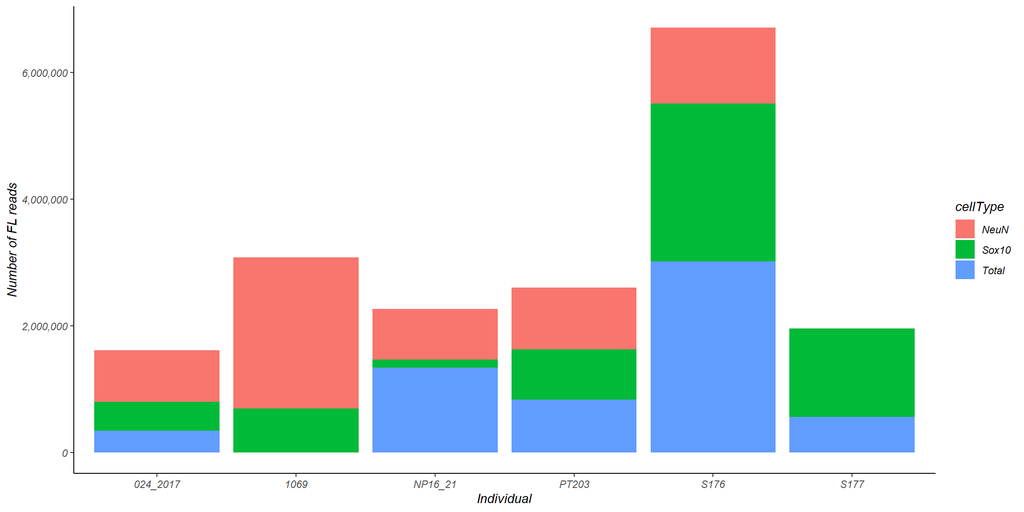

Figure: bar plot shows the number of full-length (FL) reads obtained for each individual after sequencing (pre-alignment).

## 2.2 Alignment rate

Post alignment to the reference genome, we are looking for a near-100% alignment identity (proportion of identical bases to the reference transcript) and a near-100% alignment coverage (proportion of bases matching to the reference transcript). While the alignment identity is an inherent measure of the sequencing platform (i.e. basecalling nanopore accuracy), the alignment coverage can provide insights into the sequencing library quality such that a poor alignment coverage could be suggestive of RNA degradation.

Table: summary of alignment statistics of the number of reads alignmed, the mean aligned coverage and identity of those reads

| Sample | number of reads | aligned coverage | aligned identity |
| --- | --- | --- | --- |
| BC02 | 2574327 | 0.9135957 | 0.9862047 |
| BC03 | 671945 | 0.9000339 | 0.9851366 |
| BC04 | 919163 | 0.9162643 | 0.9857648 |
| BC05 | 1134145 | 0.9205664 | 0.9848262 |
| BC06 | 881363 | 0.9175794 | 0.9853571 |
| BC07 | 385087 | 0.8883879 | 0.9839906 |
| BC08 | 913323 | 0.9119634 | 0.9845696 |
| BC09 | 459757 | 0.9026812 | 0.9854455 |
| BC10 | 609803 | 0.9108888 | 0.9847694 |
| BC12 | 1530128 | 0.9231147 | 0.9873205 |
| BC13 | 3374339 | 0.9204707 | 0.9864502 |
| BC14 | 1273868 | 0.8976311 | 0.9863210 |
| BC15 | 2769039 | 0.9294554 | 0.9865478 |
| BC16 | 1419949 | 0.9141843 | 0.9859344 |
| BC17 | 848490 | 0.8973691 | 0.9834782 |
| BC18 | 129492 | 0.9120713 | 0.9861335 |

For a transcriptome sequencing library, we are looking for a normal distribution around 1.5kb - 2kb; any peaks are indicative of RNA degradation or standards if added.

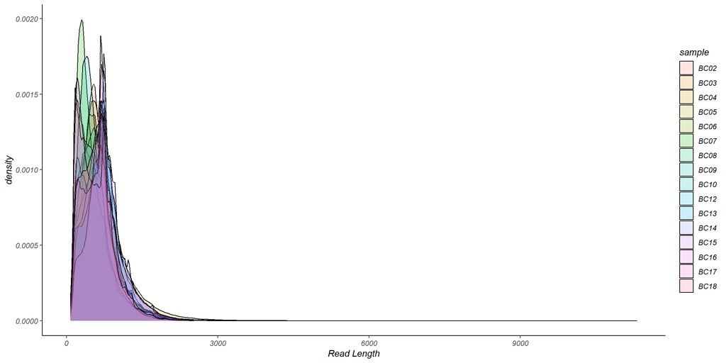

Figure: distribution of the sample read length post alignment.

## 2.3 Genome coverage

The genome coverage would depend if sequencing was performed on a whole transcriptome level or at a targeted level.

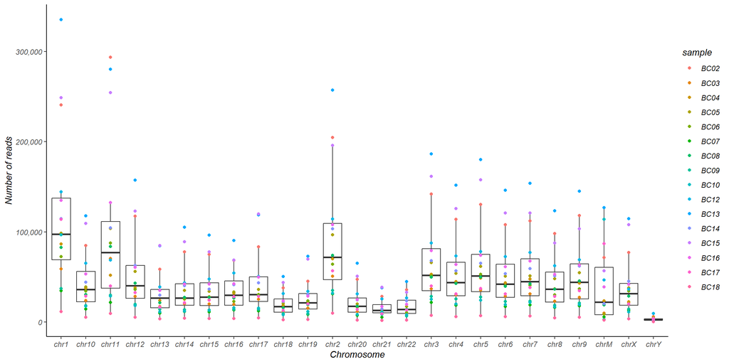

: number of reads aligned to each chromosome.

## 2.4 Standards

No ERCC molecules were added to this sequencing run; QC unavailable.

# 3 QC: Sample identity

A series of quality control (QC) sequencing metrics are provided below to ensure that the correct samples are assigned to the corresponding barcode/flow cell.

## 3.1 Sex prediction

We can use the reads aligned to the X and Y chromosome to infer the sex of the samples, by calculating a fold change of the number of reads in the corresponding X and Y chromosome relative to the total reads aligned to the allosomes (X and Y together). - For females, we would expect a near 1 fold-change on the X chromosome and a near 0 fold change on the Y chromosome.  
- For males, we would expect a near 0.5 fold change on the X chromosome and Y chromosome.

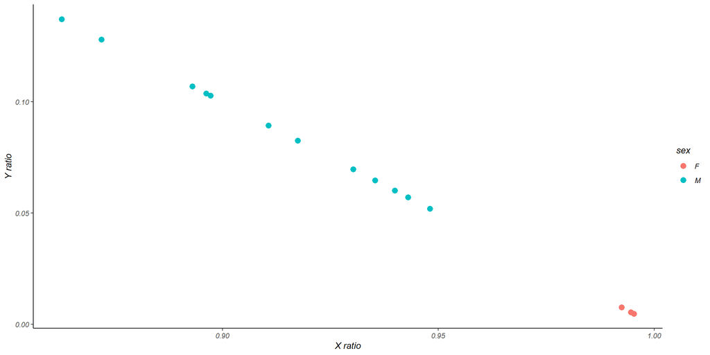

Figure: number of reads aligned to X and Y chromosome over total reads aligned to X and Y chromosome

# 4 QC: Data quality

## 4.1 RT artifacts

As part of the final bioinformatics pipieline, reads are collopsed into transcripts and are filtered by *SQANTI* if they are classified as artifacts in the form of:  
- intra-priming, defined by high percentage of A downstream of transcription termination site  
- reverse-transcription switching

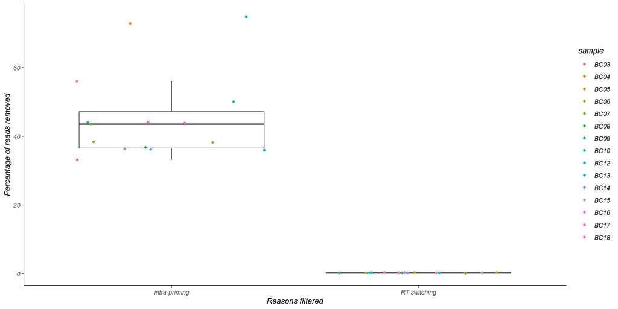

Figure: box-plot of the number of reads classified as artifacts from reverse-transcription step, and subsequently removed

## 4.2 Expression threshold

To reduce false negatives and increase confidence of identifying “true” isoforms, we can apply an expression filter threshold i.e. an isoform is kept only if it has more than 2 reads across any 2 samples.

The below plot shows the proportion of reads retained after applying a step-wise threshold. Each line corresponds to the minimum number of reads and the x-axis refers to the minimum number of samples.

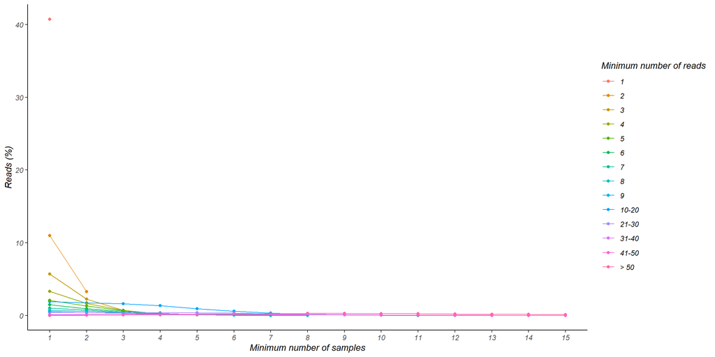

Figure: Line plot of the number of reads retained post SQANTI filtering after applying an expression threshold

# 5 QC: Sample reproducibility

We anticipate that while the number of reads may differ across the samples, the extent of reads retained after each processing step will be consistent. Any deviations will suggest a sample/batch failure.

The plot displays the proportion of reads in each sample **retained** after the following steps:  
1. Alignment and correction  
2. Collapsing reads to transcripts  
3. Filtering reads for RT artifacts  
4. Removing mono-exonic non-FSM reads  
5. Applying a minimum expression threshold

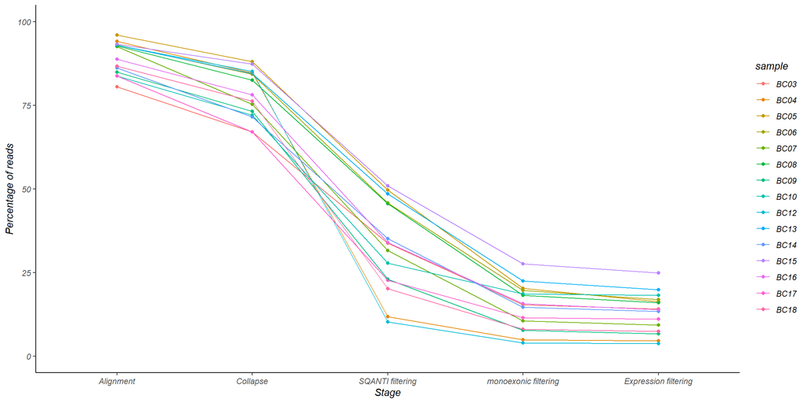

Figure: proportion of reads retained after each processing/filtering stage

# 6 QC: Biological validity

The following sections assess whether the samples sequenced reflect biological phenomena and if there are any covariates that should be accounted in downstream analysis.

## 6.1 Principle component analysis

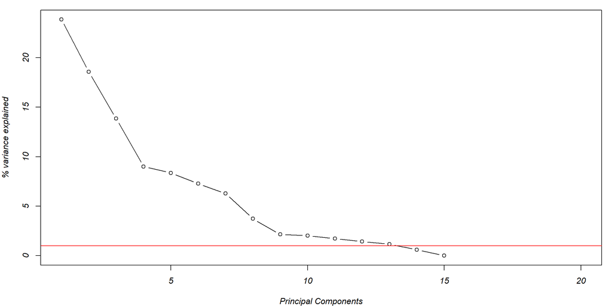

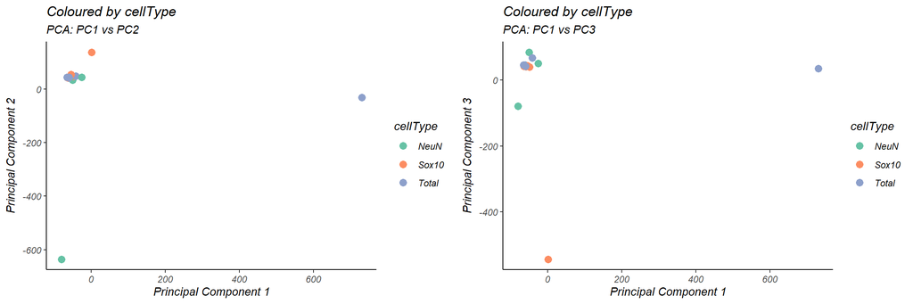

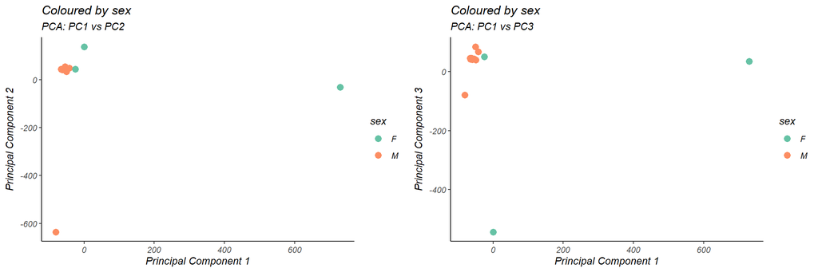

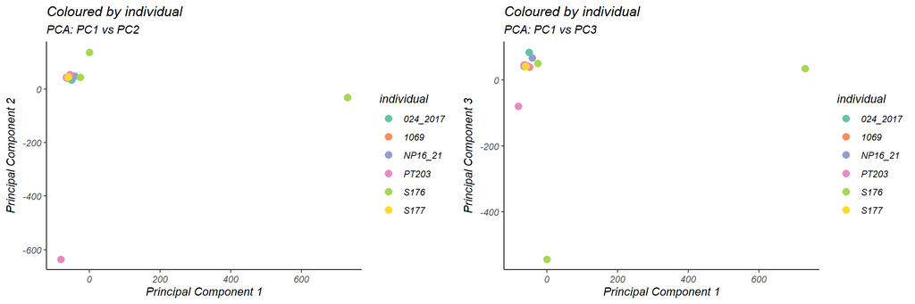

## 6.3 Gene expression

We expect the gene expression of house keeping genes to be consistent across all samples, and differences in cell-specific genes for sorted populations.

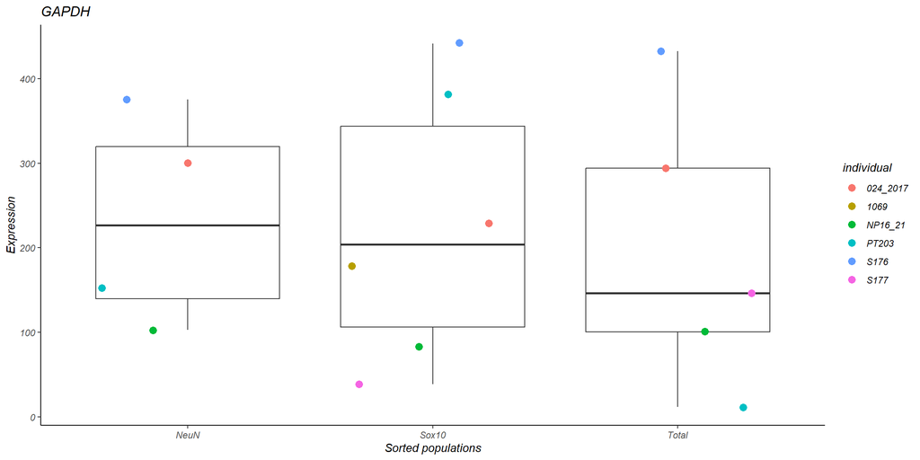

### 6.3.1 Cell-specific genes

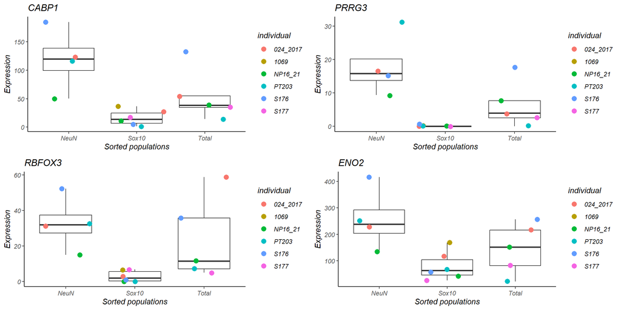

Figure: neuronal-specific gene expressions

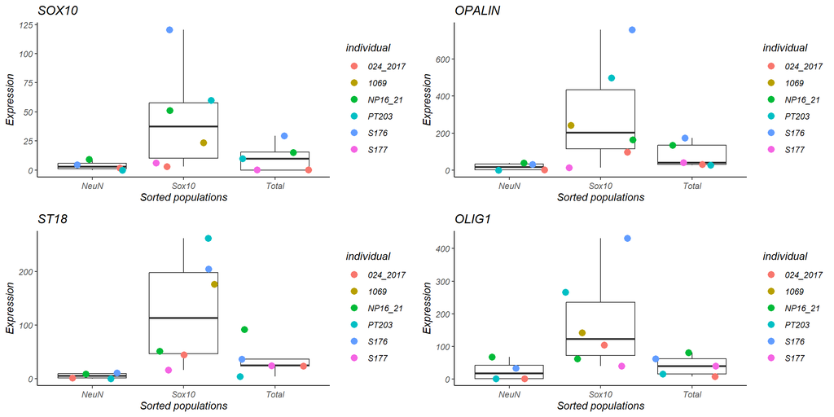

Figure: oligodendrocyte-specific gene expressions